# 311 Calls in 2015

*Kenneth Luna*

Going to use several packages for this project. “plyr” allows for data summarization while ggplot improves on visualization capabilities.

```r
library("forecast")
```

```r
library("plyr") ## for data wrangling
library("ggplot2") ## for data visualizations
```

The dataset is the number of calls to 311 services in NYC.

```r
data <- read.csv("/Users/krluna/forecastingTimeseries/Project1/new_311.csv")

data$created <- as.Date(data$created, "%m/%d/%Y %H:%M:%S %p")
data <- data[-c(64),]

date <- data$created
time <- 1:length(date)
calls <- data$count
```

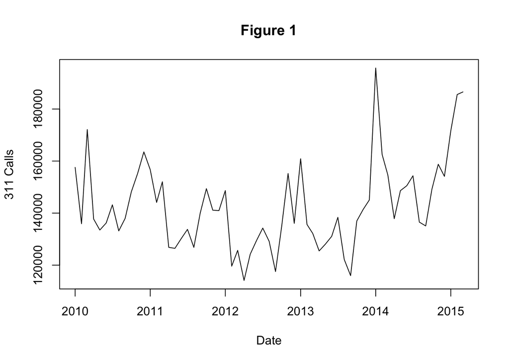

```r
par(mfrow=c(1,1))
plot(date, calls, type="l",
     xlab="Date", ylab="311 Calls", main = "Figure 1")
```

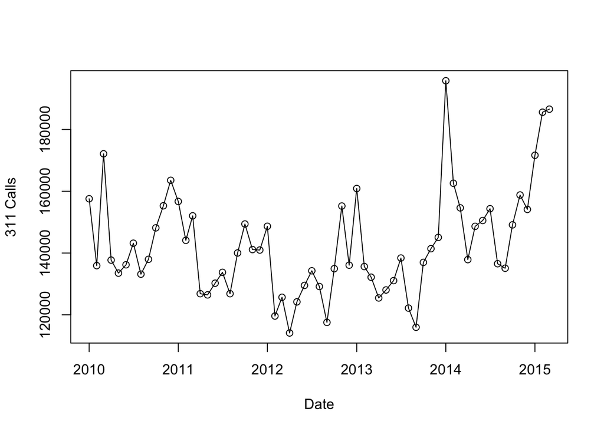

```r
plot(date, calls, type="o",
     xlab="Date", ylab="311 Calls")
```

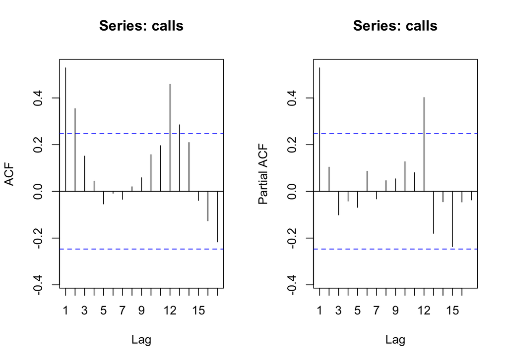

```r
par(mfrow=c(1,2))
Acf(calls)
Pacf(calls)
```

Preliminary Observations

In order to find the appropriate forecasting model, we will need to seasonally adjust this data by subtracting the monthly average across all observations. We will take the monthly average across the entire sample there is no trend.

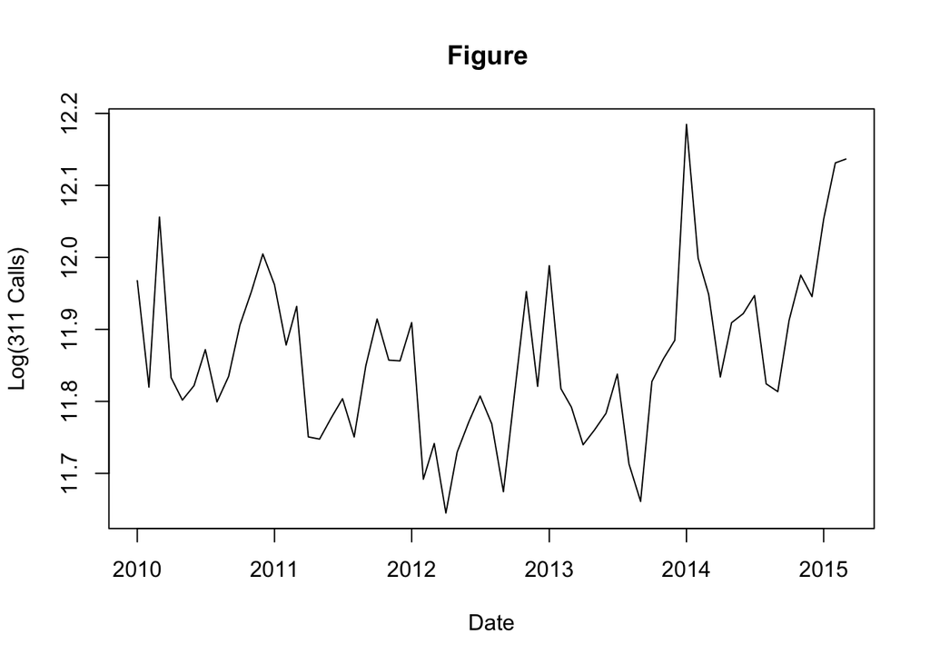

```r
log.calls <- log(calls)

par(mfrow=c(1,1))
plot(date, log.calls, type="l",
     xlab="Date", ylab="Log(311 Calls)", main = "Figure ")
```

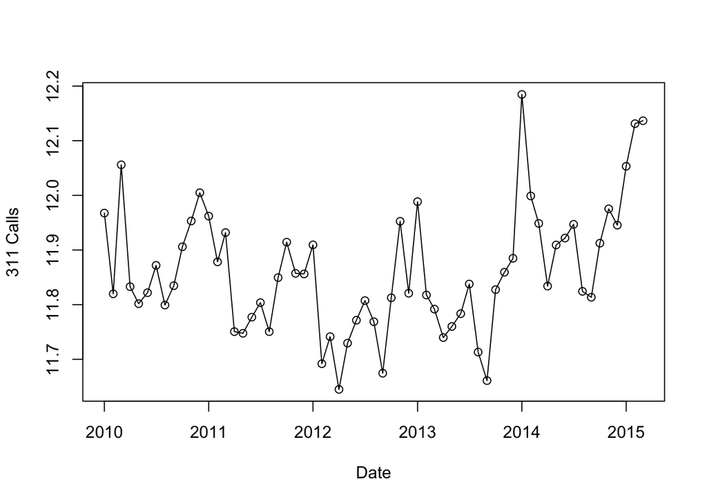

```r
plot(date, log.calls, type="o",
     xlab="Date", ylab="311 Calls")
```

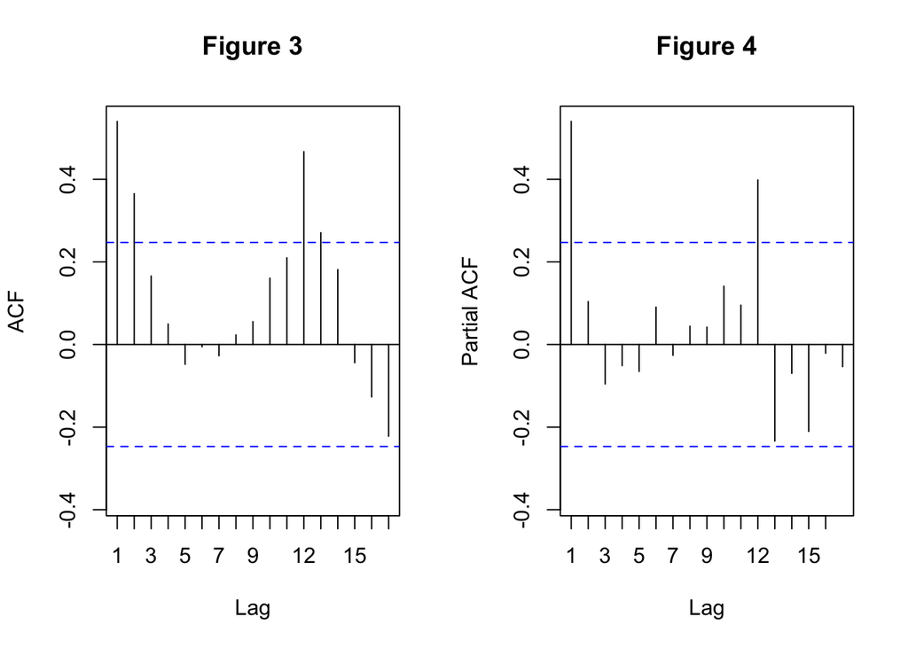

```r
par(mfrow=c(1,2))
Acf(log.calls,  main = "Figure 3")
Pacf(log.calls,  main = "Figure 4")
```

Here we get monthly averages so we can seasonally adjust:

```r
month <- factor(months(date), levels=format(ISOdate(2010,1:12,1),"%B"))
month.avg <- c(by(log.calls, month, mean))

print(month.avg)
```

```
##   January  February     March     April       May      June      July
##  12.01092  11.88966  11.93442  11.76048  11.78970  11.81521  11.85357
##    August September   October  November  December
##  11.77127  11.76670  11.87460  11.91957  11.90249
```

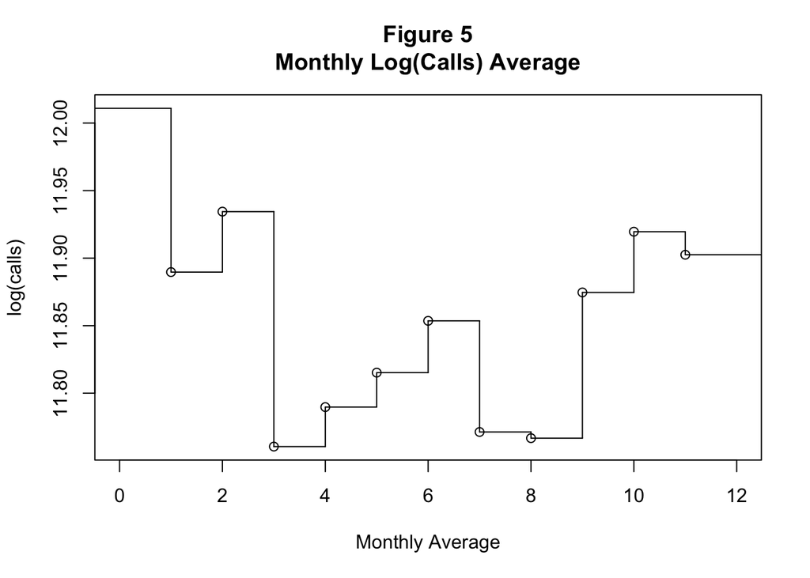

```r
avgSteps <- stepfun(1:11, month.avg, f = 0)

par(mfrow=c(1,1))
plot(avgSteps,
     xlab = "Monthly Average",
     ylab = "log(calls)",
     main = "Figure 5\nMonthly Log(Calls) Average")
```

Interestingly, we see spikes in calls during the winter months and some of the summer months; we assume that the calls in the winter are due to heating issues during the cold and the calls in the summer are due to noise complaints as everyone spends time outdoors.

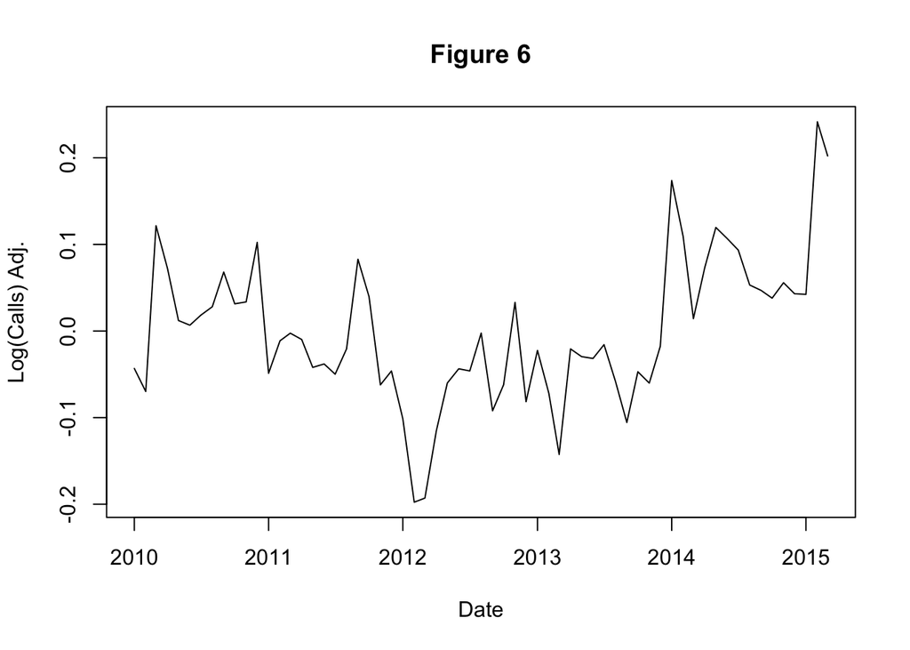

```r
log.calls.adj <- log.calls - month.avg[month]

par(mfrow=c(1,1))
plot(date, log.calls.adj, type="l",
     xlab="Date", ylab="Log(Calls) Adj.", main = "Figure 6")
```

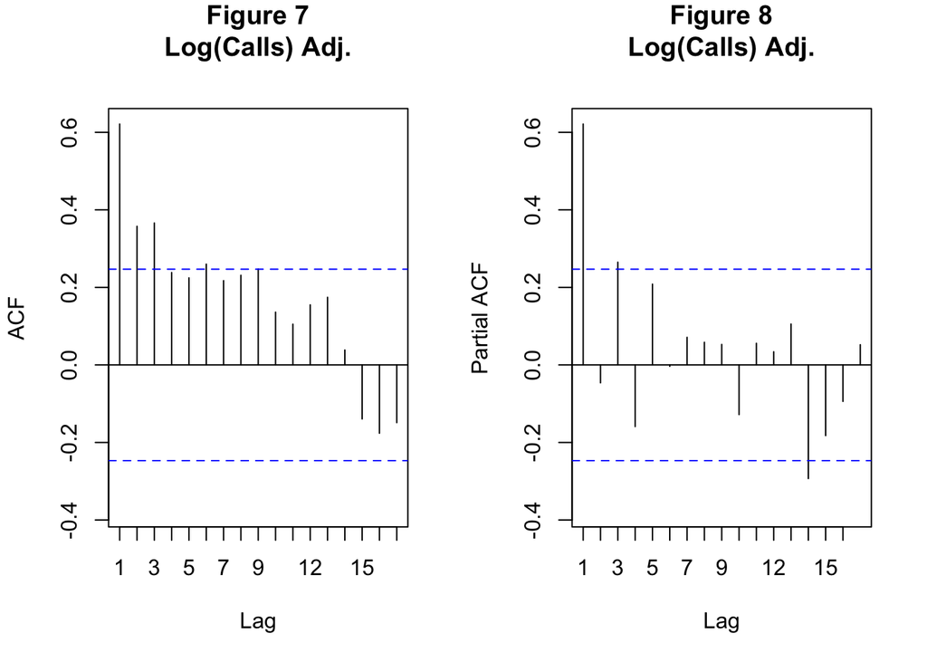

```r
par(mfrow=c(1,2))
Acf(log.calls.adj, main = "Figure 7\nLog(Calls) Adj.")
Pacf(log.calls.adj, main = "Figure 8\nLog(Calls) Adj.")
```

Based on these observations, we would suspect this is an autoregressive model as the correlogram gradually dies down while the partial coorelogram cuts off after lag-1.

```r
diff.log.calls.adj <- c(NA, diff(log.calls.adj))
diff2.log.calls.adj <- c(NA, diff(diff.log.calls.adj))
```

Differencing:

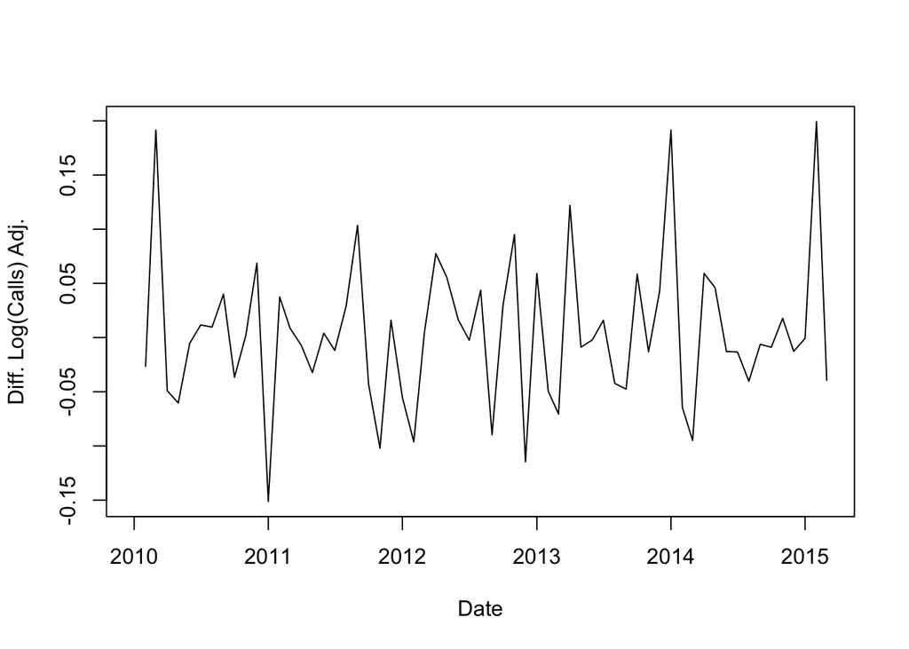

```r
par(mfrow=c(1,1))
plot(date, diff.log.calls.adj, type="l",
     xlab="Date", ylab="Diff. Log(Calls) Adj.")
```

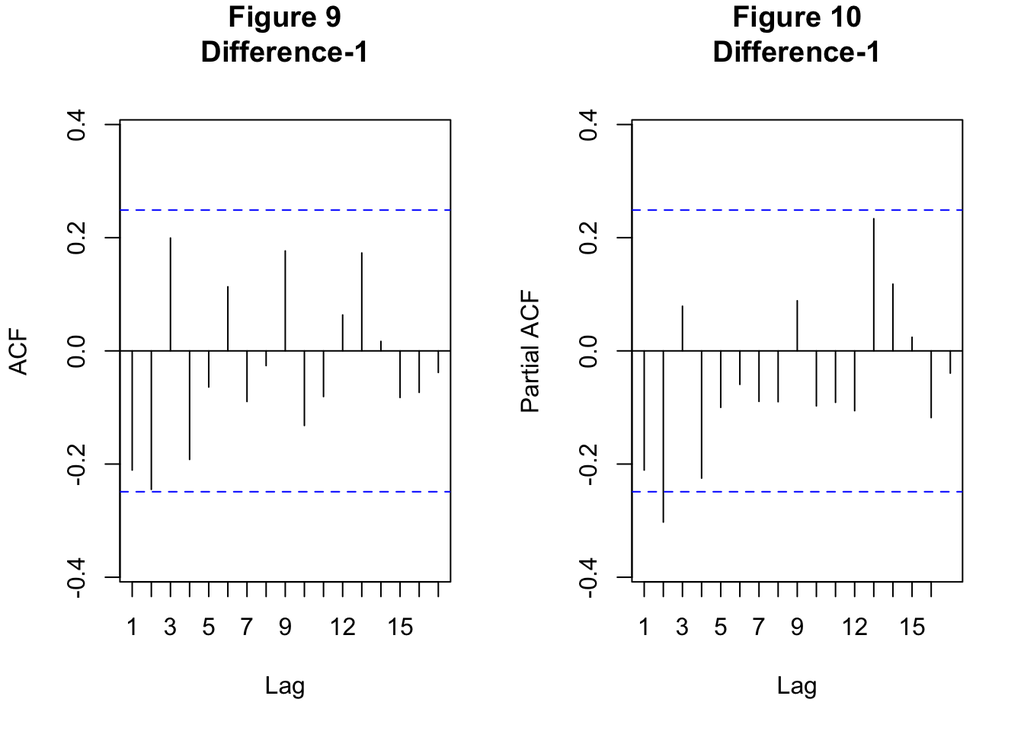

```r
par(mfrow=c(1,2))
Acf(diff.log.calls.adj, main = "Figure 9\nDifference-1")
Pacf(diff.log.calls.adj, main = "Figure 10\nDifference-1")
```

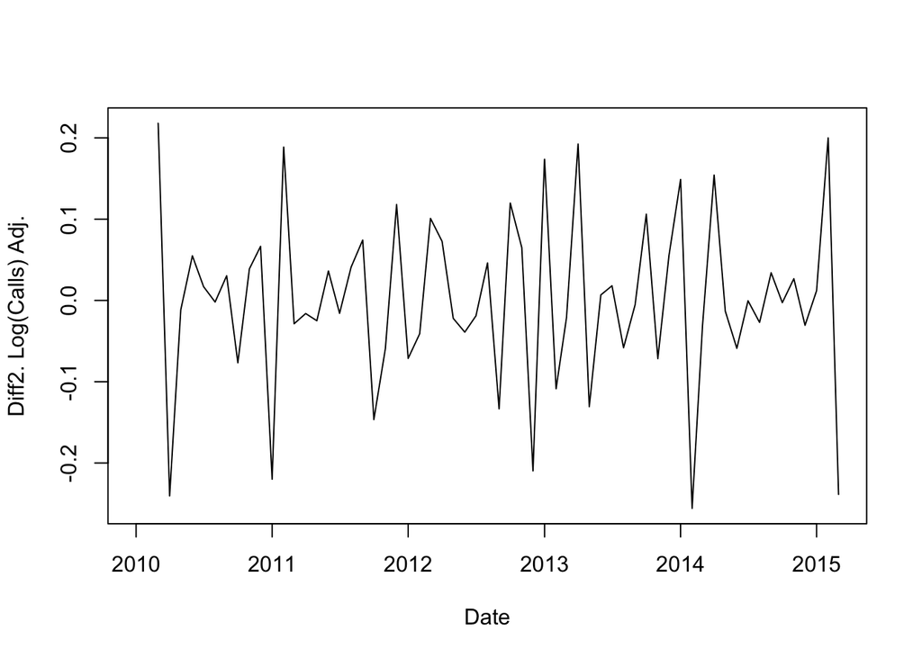

```r
par(mfrow=c(1,1))
plot(date, diff2.log.calls.adj, type="l",
     xlab="Date", ylab="Diff2. Log(Calls) Adj.")
```

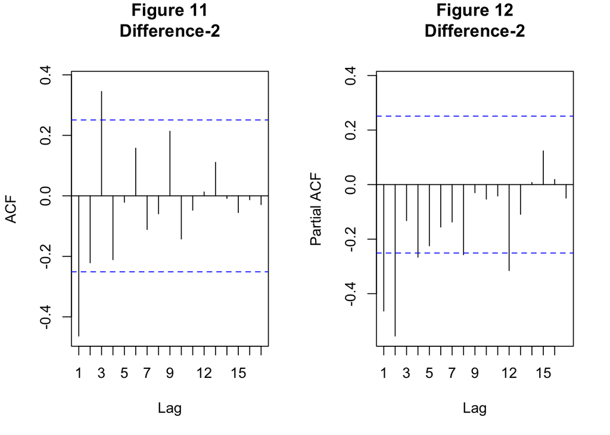

```r
par(mfrow=c(1,2))
Acf(diff2.log.calls.adj, main = "Figure 11\nDifference-2")
Pacf(diff2.log.calls.adj,  main = "Figure 12\nDifference-2")
```

Based on our observations of the 1st and 2nd difference of the seasonally adjust log(Calls), it appears that there is no need to difference. Difference-1 and Difference-2 both have lag-1 values that are fairly negative, indicating over-differencing.

```r
fit.00 <- Arima(log.calls.adj, c(0, 0, 0), include.constant=FALSE)
fit.01 <- Arima(log.calls.adj, c(0, 0, 1), include.constant=FALSE)
fit.02 <- Arima(log.calls.adj, c(0, 0, 2), include.constant=FALSE)
fit.10 <- Arima(log.calls.adj, c(1, 0, 0), include.constant=FALSE)
fit.11 <- Arima(log.calls.adj, c(1, 0, 1), include.constant=FALSE)
fit.12 <- Arima(log.calls.adj, c(1, 0, 2), include.constant=FALSE)
fit.20 <- Arima(log.calls.adj, c(2, 0, 0), include.constant=FALSE)
fit.21 <- Arima(log.calls.adj, c(2, 0, 1), include.constant=FALSE)
fit.22 <- Arima(log.calls.adj, c(2, 0, 2), include.constant=FALSE)

# With constant:
fit.00c <- Arima(log.calls.adj, c(0, 0, 0), include.constant=TRUE)
fit.01c <- Arima(log.calls.adj, c(0, 0, 1), include.constant=TRUE)
fit.02c <- Arima(log.calls.adj, c(0, 0, 2), include.constant=TRUE)
fit.10c <- Arima(log.calls.adj, c(1, 0, 0), include.constant=TRUE)
fit.11c <- Arima(log.calls.adj, c(1, 0, 1), include.constant=TRUE)
fit.12c <- Arima(log.calls.adj, c(1, 0, 2), include.constant=TRUE)
fit.20c <- Arima(log.calls.adj, c(2, 0, 0), include.constant=TRUE)
fit.21c <- Arima(log.calls.adj, c(2, 0, 1), include.constant=TRUE)
fit.22c <- Arima(log.calls.adj, c(2, 0, 2), include.constant=TRUE)

models <- data.frame(p = rep(c(0, 0, 0, 1, 1, 1, 2, 2, 2), 2),
                     d = rep(0, 18),
                     q = rep(c(0, 1, 2), 6),
                     include.constant = c(rep(FALSE, 9), rep(TRUE, 9)),
                     loglik = c(fit.00$loglik, fit.01$loglik, fit.02$loglik,
                                fit.10$loglik, fit.11$loglik, fit.12$loglik,
                                fit.20$loglik, fit.21$loglik, fit.22$loglik,
                                fit.00c$loglik, fit.01c$loglik, fit.02c$loglik,
                                fit.10c$loglik, fit.11c$loglik, fit.12c$loglik,
                                fit.20c$loglik, fit.21c$loglik, fit.22c$loglik),
                     aicc = c(fit.00$aicc, fit.01$aicc, fit.02$aicc,
                                fit.10$aicc, fit.11$aicc, fit.12$aicc,
                                fit.20$aicc, fit.21$aicc, fit.22$aicc,
                                fit.00c$aicc, fit.01c$aicc, fit.02c$aicc,
                                fit.10c$aicc, fit.11c$aicc, fit.12c$aicc,
                                fit.20c$aicc, fit.21c$aicc, fit.22c$aicc)
                     )
```

The p, d, q selected based on AICC is the ARIMA(2, 0, 2) without a constang with an AICC of -166.120.

Here is the estimated model:

```r
fit <- Arima(log.calls.adj, c(2,0,2), include.constant = FALSE)
print(fit)
```

```
## Series: log.calls.adj
## ARIMA(2,0,2) with zero mean
##
## Coefficients:
##          ar1     ar2     ma1      ma2
##       0.4622  0.3911  0.2932  -0.5413
## s.e.  0.3018  0.1873  0.3120   0.2332
##
## sigma^2 estimated as 0.003434:  log likelihood=88.59
## AIC=-167.18   AICc=-166.12   BIC=-156.46
```

```r
(1-pnorm(abs(fit$coef)/sqrt(diag(fit$var.coef))))*2
```

```
##        ar1        ar2        ma1        ma2
## 0.12569801 0.03681549 0.34745029 0.02026933
```

x(t) = .4622 * x(t-1) + .3911 * x(t-2) + eps(t) + .2932 * eps(t-1) + -.5413 * eps(t-2)

```r
resid <- residuals(fit)

lb12 <- Box.test(resid, lag=12, type = "Ljung-Box", fitdf=4)
lb24 <- Box.test(resid, lag=24, type = "Ljung-Box", fitdf=4)
lb36 <- Box.test(resid, lag=36, type = "Ljung-Box", fitdf=4)
lb48 <- Box.test(resid, lag=48, type = "Ljung-Box", fitdf=4)
```